# Crash Course on Where I Stand

## Crash Course in R

**Basics of R**

There are different data types in R - integers, doubles/numerics, logicals, and characters. Integers are values like -1, 0, 2, 4092. Doubles or numerics are a larger set of values containing both the integers but also fractions and decimal values like -24.932 and 0.8. Logicals are either TRUE or FALSE while characters are text such as “The Newsroom is the greatest TV show ever”. They are often denoted with the quotation marks around them.

Vectors are series of values created by the `c()` function, where `c(2,3,5,7)` would be a four element series. Factors are ways of representing categorical data. Data frames are rectangular spreadsheets.

We can test for equality using `==`, and do Boolean algebra using mathematical operators such as `>`, `>=` and `!=`. There are also the logical operators of `&` (and) as well as `|` (or).

We can explore data frames by using RStudio’s data viewer with `View()`, using `glimpse()` in the `dplyr` package, using `kable()` in the `knitr` package (which is R Markdown friendly) and using `$` for looking at a single variable or column. Within a data frame, there are identification variables and measurement/characteristic variables.

**Data Science with tidyverse**

We can visualise data with `ggplot2`. A statistical graphic is a `mapping` of `data` variables onto the `aes`thetic attributes of `geo`metric objects. This can be be presented with `facet`ing the data into several plots, and with `position` adjustments for barplots.

For example, we can take a hypothetical `data_frame` and plot it via `ggplot(data = data_frame, mapping = aes(x = independent_var, y = dependent_var)) + geom_point()` to get a scatterplot. Because the points may overlap and cause overplotting, we can specify `geom_point(alpha = 0.2)` to increase the transparency of each point or jitter the points by `geom_jitter(width = 10, height = 10)`. We can get a linegraph with `geom_line()`. We can get a histogram with white borders and blue steel bins using `geom_histogram(color = "white", fill = "steelblue")`. The bins can be adjusted by using the `bins` argument or the `binwidth` argument. We can add `+ facet_wrap(~ month, nrow = 4)` to separate the plot into one plot for each month across 4 rows, if `month` is in the data frame. A boxplot can be created via `geom_boxplot()` - but for categorical variables, we can do `ggplot(data = data_frame, mapping = aes(x = factor(categorical_var), y = dependent_var)) + geom_boxplot()`. Finally, we have barplots - if the categorical data is listed individually, we use `geom_bar()`, while if it is pre-counted, we use `geom_col()`.

This gets more complicated with multiple categorical variables - we can use `ggplot(data = data_frame, mapping = aes(x = first_var, fill = second_var)) + geom_bar(position = "dodge")` to get side-by-side barplots or use `facet_wrap(~ second_var)` to get a faceted barplot.

We can wrangle data using `dplyr`. The pipe operator `%>%` takes the output of the previous function and inputs it into the next function. The `filter()` function filters out the data based on some criteria regarding the values of variables. We can find various summary statistics by `summary_values <- data_frame %>% summarise(mean = mean(some_var, na.rm = TRUE), std_dev = sd(some_var, na.rm = TRUE))`, which removes all missing values. There are other summary statistics, such as `max()`, `min()`, `IQR()`, `sum()` and `n()`.

We can group observations by the value of another variable using the function `group_by(first_var, second_var)`. We can transform data by using `mutate()`, such as `data_frame <- data_frame %>% mutate(new_var = second_var - first_var)`. To order data, we can pipe a data frame into `arrange()` or `arrange(desc())`, which will sort it by some variable.

Data frames can be merged, with `data_frame_joined <- first_data_frame %>% inner_join(second_data_frame, by = "some_var")`. If we want to join data frames with variables that have different names in the two data frames, we can use `by = c("first_name" = "second_name")`. By contrast, if we want to join data frames by multiple key variables (because that is required to uniquely identify each observational unit), we can use `by = c("first_var","second_var","third_var")`. Other ways of wrangling data including using `select()` to pick a subset of variables or columns - the argument `-first_var` excludes `first_var`, `first_col:nth_col` selects the range of columns from `first_col` to `nth_col`, and the helper functions of `starts_with()`, `ends_with()` and `contains()` can be used. The `rename(new_name = old_name)` function can rename variables, while we can select the first `n` values of a variable using `top_n(n = 10, wt = chosen_var)`.

We can import data with `readr`. We can import a csv using `read_csv()`. We then need to tidy the data - tidy data is where each variable forms a column, where each observation forms a row, and where each type of observational unit forms a table. We can convert to tidy format using with the `tidyr` package and the function `pivot_longer(names_to = "", values_to = "", cols = )`.

For more, check out the cheatsheets on the Rstudio website.

**Data Modeling with moderndive**

We can model for explanation or for prediction - that is, make explicit the relationship between an outcome/dependent variable $y$ and an explanatory/predictor/independent variable $x$. The `tidyverse` package includes a set of data wranggling packages, the `moderndive` package allows linear regression and `skimr` can compute summary statistics.

Before doing any modeling, we should perform an exploratory data analysis. This involves looking at raw data values with `glimpse()`, computing summary statistics with `skim()` and `get_correlation()` as well as creating data visualisations.

To begin with, we have a numerical outcome variable and a single numerical explanatory variable - the following plots them out alongside a regression line based on a linear model, with standard error uncertainty bars.

```
ggplot(data_frame, aes(x = explanatory_var, y = outcome_var)) +
  geom_point() +
  labs(x = "Explanatory", y = "Outcome",
       title = "Relationship between explanatory and outcome") +
  geom_smooth(method = "lm", se = TRUE)
```

We can then analyse the data.

```
model <- lm(outcome_var ~ explanatory_var, data = data_frame)
get_regression_table(model)
```

We can repeat this process with a numerical outcome variable and a single categorical explanatory variable. We can make a regression table and use that to produce an equation with indicator functions. We can examine the specifics of the model by looking at the points.

```
regression_points <- get_regression_points(model)
```

For a numerical outcome variable with two explanatory variables, one numerical and one categorical, we can plot it and use colours to distinguish, and then fit the model to an interaction model.

```
ggplot(data_frame, aes(x = num_var, y = outcome_var, color = cat_var)) +
  geom_point() +
  labs(x = "Numerical", y = "Outcome", color = "Categorical") +
  geom_smooth(method = "lm", se = FALSE)

model <- lm(outcome_var ~ num_var * cat_var, data = data_frame)
get_regression_table(model)
```

In some cases, we may want to use a parallel slopes model.

```
ggplot(data_frame, aes(x = num_var, y = outcome_var, color = cat_var)) +
  geom_point() +
  labs(x = "Numerical", y = "Outcome", color = "Categorical") +
  geom_parallel_slopes(se = FALSE)

model <- lm(outcome_var ~ num_var + cat_var, data = data_frame)
get_regression_table(model)
```

These processes are also possible when it is two numerical explanatory variables instead.

**Statistical Inference with infer**

We take samples of a population using `rep_sample_n(size = 25, reps = 100)`. We can then plot the sampling distributions and calculate point estimates. The standard deviation of point estimates is called the standard error. As the sample size increases, the standard error will decrease and lead to a more precise estimate, as well as the sampling distribution more closely following the normal distribution.

We can engage in bootstrap resampling with replacement - that is, we resample the single sample from the population multiple times.

```
sample_data %>%
rep_sample_n(size = 50, replace = TRUE, reps = 1000) %>%
group_by(replicate) %>%
summarise(mean_value = mean(value))
```

We can construct confidence intervals with the percentile method, where a certain percentage of the resampled values fall in that range. We can also express it in terms of the standard error - however, this is dependent upon the bootstrap distribution being roughly normal.

Let’s apply the tools of `infer`, which are more powerful than the `dplyr` tools we have used so far. We `specify()` the variables of interest, `generate()` replicates and `calculate()` summary statistics.

```
sample_data <- data %>% rep_sample_n(size = 50)

sample_data %>%
specify(formula = value ~ NULL) %>%
generate(reps = 1000) %>%
calculate(stat = "mean")
```

We can pipe the distribution into `get_confidence_interval(level = 0.95, type = "percentile")` and print it, or add the argument `+ shade_ci(endpoints = )`. The alternative is possible with `get_confidence_interval(type = "se", point_estimate = )`

Another method of statistical inference is hypothesis testing. This compares a null hypothesis $H_0$ with an alternative hypothesis $H_1$, with the null hypothesis normally being the claim of no effect. We look at the null distribution of the test statistic and compare it to the observed test statistic - the p-value quantifies the probability of obtaining a test statistic just as or more extreme than the observed value assuming the null hypothesis to be true. We compare it to the significance level $\alpha$ - if it is smaller than $\alpha$, we reject the null hypothesis.

We can use another `infer` workflow to do so - we have a choice whether we are testing a point hypothesis or an independence hypothesis.

```
null_distribution <- data_frame %>%
specify(formula = outcome_var ~ explanatory_var, success = "") %>%
hypothesize(null = "independence") %>%
generate(reps = 1000, type = "permute") %>%
calculate(stat = "diff in props", order = c("male", "female"))

obs_diff_prop <- data_frame %>%
specify(formula = outcome_var ~ explanatory_var, success = "") %>%
calculate(stat = "diff in props", order = c("male", "female"))

visualize(null_distribution, bins = 10) + shade_p_value(obs_stat = obs_diff_prop, direction = "right")

null_distribution %>% get_p_value(obs_stat = obs_diff_prop, direction = "right")
```

There are two types of errors - Type 1 is rejecting $H_0$ when it is true, while Type 2 is failing to reject $H_0$ when it is false. The probability of Type 1 is the significance level of the test $\alpha$, while the probability of Type 2 is $\beta$, while the power of the test is $1-\beta$. In practice, we fix $\alpha$ and attempt to minimise $\beta$.

We can conduct inference for regression based on 4 conditions of LINE. Firstly, the linearity of relationship between variables. Secondly, the independence of the residuals. Thirdly, the normality of the residuals. Fourthly, equality of variance of the residuals. If instead the spread of the residuals increases as the value of the explanatory variable does, it displays heteroskedasticity and does not fulfil the criterion.

## Introductory Microeconomics

**Microeconomics - What is it about?**

The foundational question of microeconomics is: “how should we allocate scarce resources to meeting competing ends?” Given the billions of goods and services and billions of people, this is a difficult question to answer. Suppose we have a consumer - when they consume, they get satisfaction. We will call the satisfaction of consuming one extra unit of something its marginal utility. Suppose we have a firm - when it produces, it costs them resources (land, labour, capital and enterprise). We will call the cost of producing one extra unit of something its marginal cost. One way to think about our foundational question is allocative efficiency. That is where the following holds.
$$\frac{MU1}{MC1} = \frac{MU2}{MC2}$$
Consider what happens if $\frac{MU1}{MC1}>\frac{MU1}{MC1}$? That means the “bang per buck” of producing the next unit of good 1 is greater than of good 2 - in that case, society should be making more of good 1 until these two equalise. In the real world, we have hundreds of thousands of $\frac{MU}{MC}$ ratios - how could we possibly equalise all of those? And how do we even know what the marginal utility and marginal cost of a good is to every single person? This feels like an intractable problem.

**Microeconomics - How do markets work?**

Let’s introduce prices - that is, consumers pay prices for things. In that case, consumers will allocate their spending in the following way.
$$\frac{MU1}{P1} = \frac{MU2}{P2}$$
The reasoning for this is similar to how we get the condition for allocative efficiency. Consider what happens when they aren’t equal - consumers will reallocate their spending until they are equal. And they are able to do this because we assume that goods provide a diminishing marginal utility as you get more of it. Producers will be producing in the following way.
$$P = MC$$
If $P > MC$, producers would keep producing more of that good, since selling it would be profitable. And they will make enough of it until the two equalise, which occurs because the marginal cost of producing stuff increases. Consider if I am a farmer - I’ll start with my most fertile piece of land and use the next most fertile piece and so on - and so as I produce more, I’m getting less out of the land.

In both of these cases, neither consumers nor producers needed to worry about the other side - they just needed to compare their own utility or costs to the price. And we can combine the equations we have so far in the following way.
$$\frac{MU1}{P1} = \frac{MU2}{P2}$$
$$P1 = MC1$$
$$P2 = MC2$$
$$\frac{MU1}{MC1} = \frac{MU2}{MC2}$$
And we get the condition for allocative efficiency. That’s the thing - prices are signals that allow people to coordinate in an allocatively efficient way, without needing to know all the information.

**Microeconomics - How do markets fail?**

We have seen the utopia of free market magic. But what happens when there’s a monopoly for good 1? Because no one forces them to drive down the price due to their market power, they can set $P1>MC1$. If we combine the equations as we did before, we get a problematic outcome.
$$P1 > MC1$$
$$P2 = MC2$$
$$\frac{MU1}{P1} = \frac{MU2}{P2}$$
$$\frac{MU1}{MC1} > \frac{MU2}{MC2}$$
The monopoly has distorted the market, increasing the price of a good such that we produce too little of it. We can see it is too little, because the “bang per buck” for good 1 is greater than for good 2.

Now let’s consider what happens when producing a good causes spillover benefits or costs onto third parties, who are not involve in the transaction. For example, the coal power plant emits some air pollution. This means that our efficiency condition should look at the marginal social utility and marginal social cost - that is, considering both the private benefits and costs, as well as the spillovers.
$$\frac{MSU1}{MSC1}=\frac{MSU2}{MSC2}$$
Suppose good 1 generates a negative externality, which is not reflected in the price. We can do the same analysis as before.
$$P1 < MSC1$$
$$P2 = MSC2$$
$$\frac{MU1}{P1} = \frac{MU2}{P2}$$
$$\frac{MU1}{MSC1} < \frac{MU2}{MSC2}$$
Because the price signal does not incorporate the external spillovers i.e. all the costs of producing the good, we end up producing too much of good 1.

Let’s introduce two terms - non-rival and non-excludable. Non-rival means that my consumption of the good doesn’t diminish your consumption of the same good. Non-excludable means that it is not possible to stop someone from using the good. We can look at the 4 categories of goods and services based on these two criteria. - Rival and excludable: markets are good at producing these goods. These are most goods we usually think about. - Rival but non-excludable: the tragedy of the commons, where markets tend to over-consume these goods. Consider why over-fishing occurs. - Non-rival but excludable: markets tend to under-provide these goods. Think of research and development, where me using an idea doesn’t stop you, but where I can lock you out with patents or JSTOR paywalls. - Non-rival and non-excludable: these are public goods, which markets are bad at providing due to the free rider problem. The military is an example of a public good - once it exists, it is hard to exclude someone in your country from its protection.

One assumption we have made is that people have perfect information. In practice, consumers may have imperfect information about the costs and benefits of a good. This can lead to them misjudging the marginal utility. By contrast, asymmetric information is where one party has information the other doesn’t. This can create moral hazard, where someone has the ability and incentive to shift the costs onto someone else. For example, if you have fire insurance, you are less likely to buy a fire extinguisher, because the costs are passed onto the insurance company. This is a problem, because the total societal cost is raised. Asymmetric information can also create a principal-agent problem. That is where the principal is unable to fully monitor the behaviour of the agent, who they have tasked with doing something. For example, it is difficult for someone to know if all the prescriptions a doctor recommends is correct and necessary, while they may have the incentive to tell you that you need more than you do, in order to increase their billables. Finally, information asymmetry can lead to adverse selection. Consider a market of used cars, where half are “peaches” that are good, and half are "lemons’ which are bad. If you are a buyer, you are unable to tell which is which - and so you are only willing to pay the average of how much you value peaches and lemons. That causes the sellers of peaches to leave the market - and so you are left with a missing market.

**Microeconomics - How do governments work?**

Governments can help correct for market failures. If there is a monopoly, they can regulate it away via anti-trust laws. xternalities could be dealt with by government taxation. Imagine a tax such that $(1+t)P=MSC$ - this forces people to bear the external costs, making the price signal an accurate reflection of the social costs. Another mechanism is by regulating the quantity of production - the most obvious is carbon cap-and-trade systems. The question of which to use depends on whether it is easier to estimate the optimal price or optimal quantity. Governments can help provide public goods. They can also help regulate the commons - for example, one of the ways to reduce over-hunting is to fence off bits of land and give people permits to hunt on their piece. Because that area is theirs, the government has transformed it from non-excludable to excludable, solving the problem. Finally, informational problems may simply require informational solutions. Governments can help educate the public or make informational access easier.

**Microeconomics - How do governments fail?**

We’ve seen how governments can help correct market failures - but they can themselves create government failures, if they step in when there isn’t something to be fixed. Consider what happens to our original allocative efficiency conditions if they impose a tax. This will distort the price signal. A price ceiling, price floor or quota will also disrupt the allocative mechanism. This is not to mention the fact that governments are not omniscient beings, and so they could themselves make mistakes. And there is a danger of regulatory capture, where regulators become co-opted to serve a specific constituency. Therefore a useful three-step process is to think: 1. What is the market failure? 2. Is the intervention likely to fix the market failure, or will it simply create a government failure? 3. Is the market failure so bad you need the government to step in for direct provision?

## Some Macroeconomic Facts

**Macroeconomics - The Timeframes**

In the ultra short run of the few months, the main adjustment mechanism is inventories. Prices and capital are fixed. In the short run of up to a few years, the main adjustment mechanism is prices. Capital remains quasi-fixed. In the medium run of around a decade, the main adjustment mechanism is capital. Firms enter and exit at this scale. In the long run, everything has adjusted. There are low-frequency fluctuations due to population growth and technological advances.

**Macroeconomics - Long-Run Growth**

Economic growth in the long run comes from increase total factor productivity - that is, improvements in technology and resource utilisation. That means a useful long-run strategy is to find more cost-effective methods of production and introduce new goods. This is Easterly and Levine 2000, “It’s Not Factor Accumulation” or Jones 1995, “Growth: With or Without Scale Effects?”.

Nonetheless, the basic Solow model where factor accumulation occurs can be a useful core of growth theory. That means a useful medium-run strategy is to increase your capital stock, educate your workforce, urbanise and open up to international trade. This is Mankiw, Romer, and Weil 1992, “A Contribution to the Empirics of Economic Growth”.

Conditional convergence is the dominant paradigm, although convergence itself isn’t. This is Barro and Sala-i-Martin 1991, “Convergence” or Barro and Sala-i-Martin 1991, “Convergence across States and Regions”.

In the long run, the price level is proportional to the level of the money stock and the inflation rate is proportional to the growth rate of the money stock. This is the quantity theory of money. In the long run, the level and growth rate of output is independent of the money stock and its growth rate. This is the neutrality of money - that is, you cannot print yourself rich. These are Hume 1752, “Of Money” or Lucas 1995, “Monetary Neutrality” or McCandless and Weber 1995 “Some Monetary Facts”.

**Macroeconomics - Short-Run Business Cycles**

In the short run, fluctuations in aggregate demand lead to fluctuations in real GDP and in inflation, due to various market frictions, rigidities and imperfections. We would like to minimise these fluctuations.

Inflation is a monetary phenomenon, so monetary policy can aim at keeping inflation low and stable. Monetary policy can affect output growth and inflation in the short run via the Phillips Curve relationship. This is Christiano, Eichenbaum, and Evans 1999, “Monetary Policy Shocks”. Hence stabilisation policy can usefully mitigate business cycle fluctuations. This is Friedman 1968, “The Role of Monetary Policy” or Eichenbaum 1998, “Some Thoughts on Practical Stabilization Policy” or Svensson 2008, “What have we learned in the past 50 years”.

Monetary policy faces a time lag in affecting macroeconomic aggregates, so central banks should target forecasted future aggregate demand by “leaning against the wind”. This is Svensson 1997, “Inflation Forecast Targeting”. Dealing with aggregate supply shocks is more difficult than dealing with aggregate demand shocks, because they push inflation and real GDP growth in different directions. Dealing with credit or financial shocks is difficult, because they disrupt the mechanism of monetary policy.

Monetary policy should be based on systematic and predictable rules, rather than discretionary choices. This is Kydland and Prescott 1977, “Rules rather than Discretion”. Macroeconomic policy is affected by expectations, and so statistical correlations may break down if policymakers try to exploit them. This is Lucas 1972, “Expectations and the Neutrality of Money” or Lucas 1976, “Econometric Policy Evaluation: A Critique”.

If monetary policy is stabilising the business cycle, there is little role for countercyclical fiscal policy. This is Auerbach 2002, “Is there a role for discretionary fiscal policy” or Taylor 2000, “Reassessing Discretionary Fiscal Policy”. Fiscal policy should focus on microeconomic issues, such as public goods provision, social insurance provision, reasonably non-distortive taxation, and sensible regulation practices. In other words, government should be an insurance company with an army. If monetary policy is unwilling or unable to do so, activist fiscal policy may be required to rectify fluctuations in aggregate demand. We know that monetary expansion is expansionary and fiscal contraction is contractionary.

**Macroeconomics - International Trade and Finance**

In the long run, exchange rates reflect purchasing power parity. This is Rogoff 1996, “The PPP Puzzle”.

## Basic Macroeconomic Modelling

**Macroeconomics - Basic IS-LM Modelling**

Let’s begin with the the specifications of our macroeconomic model. We have output $y$, price level $p$, interest rate $r$, fiscal variable $g$, monetary variable $m$, and nominal wage $w$. The Investment-Savings curve $y = g - br$ describes the goods market - it shows combinations of interest rates associated with output. The Liquidity Preference-Money Supply curve $m - p = y - hr$ describes the money market - it shows the combinations of interest rates and real income for which money supply equals money demand. Together, they describe the equilibrium level of $(y,r)$ given some policy variables $(g,m)$ and price level $p$.

We can move to a system that solves for $(y,p)$ endogenously. We can combine IS-LM into a single equation to eliminate the interest rate.
$$y = \frac{h}{b+h}g + \frac{b}{b+h} (m-p)$$
This is a downward-sloping aggregate demand curve in $(y,p)$ space, with the slope $-\frac{b}{b+h}$ and is shifted right by monetary and fiscal policy.

One modern approach has been to look at the IS-MP model instead of IS-LM. This looks at monetary policy in its modern form, with interest rates at the forefront - it takes the form $r = \frac{1}{h} (p+y-m)$. But the equation is the same as before, simply configured differently - and so this is a pedagogical rather than substantive distinction.

We can add an aggregate supply curve, with its slope describing how a change in AD is split among price and output and its intercept being affected by the rigid nominal wage.
$$p = w + ay$$
This combination allows us to have a system of equations to understand how changes in policy variables $(g,m,w)$ affect endogenous variables $(y,p,r)$.

**Macroeconomics - Diagrammatic IS-LM Modelling**

We can derive the AD and SRAS curves graphically. Take an IS-LM diagram. Keep nominal money constant while increasing the price level. This shifts the LM curve upwards, meaning that a higher price level leads to a lower output. Thus we have the AD curve. Now take the labour market. Keep nominal wages constant while increasing the price level. This increases hours worked. We can see that more hours worked increases output in the production function diagram. We can combine this to produce the SRAS.

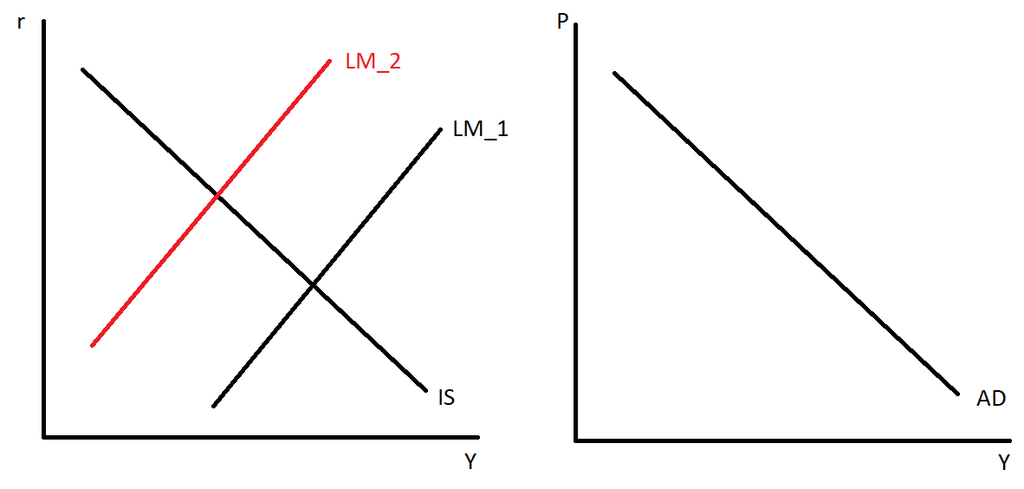

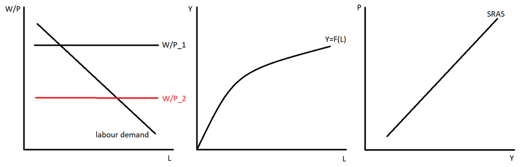

**Macroeconomics - New Keynesian AD-AS Modelling**

The New Keynesian world can be represented by a three equation system of IS-MP-PC that becomes an AD-AS model. We have an IS curve relating short-run output to the difference between the real interest rate and the natural interest rate (marginal return on capital) as well as a shock parameter. We have an MP curve setting the nominal interest rate based on a Taylor Rule, which affects the real interest rate via sticky inflation and the Fisher equation. We have an expectations-augmented Phillips Curve relating inflation to expected inflation (based on adaptive expectations of previous inflation), the output gap and a shock parameter.
$$\tilde{Y_t} = \bar{a} - \bar{b} (R_t - \bar{r})$$
$$R_t - \bar{r} = \bar{m} (\pi_t - \bar{\pi})$$
$$\pi_t = \pi_{t-1} + \bar{v} \tilde{Y_t} + \bar{o}$$
We can combine IS-MP into AD as $\tilde{Y_t} = \bar{a} - \bar{b} \bar{m} (\pi_t - \bar{\pi})$ and take PC as AS, to produce a dynamic AD-AS model relating inflation with short-run output, rather than relating the price level to output.

## History of Macroeconomic Thought

**Macroeconomics - Its History**

Macroeconomics in its proper was kickstarted by John Maynard Keynes in *The General Theory of Employment, Interest and Money*, published in 1936. Until the mid-60s, Old Keynesian macroeconomic research by the likes of John Hicks, Paul Samuelson and Don Patinkin was focused on *The General Theory*. This occurred alongside research into neoclassical growth theory by Robert Solow, Trevor Swan, David Cass and Tjalling Koopmans, which is typified by Solow’s 1956 “A Contribution to the Theory of Economic Growth”. Within microeconomic research, Kenneth Arrow, Gérard Debreu and Lionel McKenzie were building up the core of general equilibrium microeconomic theory - this would be best represented by Debreu’s *A Theory of Value* in 1959. These would be put together into the neoclassical synthesis, epitomised by Patinkin’s *Money, Interest, and Prices* in 1965.

Then came Edward Prescott and Fynn Kydland’s “Time to Build and Aggregate Fluctuations”. This kicked off real business cycle theory, and the third wave of critiques on Keynesian macroeconomics. Premised on general equilibrium theory and growth theory, this kickstarted the use of new mathematical and methodological tools in macroeconomics. Coupled with their explanation of business cycles as due to technological shocks, this allowed for quantitative models of economic fluctuations. Many young scholars like Gary Hansen, John Long and Charles Plosser joined in this approach, culminating in Thomas Cooley’s *Frontiers of Business Cycle Theory* in 1995.

So what were saltwater economists up to during all of this? They decided to incorporate elements of all of these critiques - they began emphasising the role of monetary policy and inflation expectations as argued for by the monetarists, the microeconomic foundations, intertemporal optimising behaviour and forward-looking agents as posited by the New Classicals, as well as the quantitative modelling, calibration of structural parameters and supply-side focus of the RBCists. But the lack of frictions and rigidities in many of these critiques meant that saltwater macroeconomists decided to adopt all of this while incorporating their own insights on market failures and such. This New Keynesian macroeconomics was spearheaded by economists such as John Taylor, Guillermo Calvo and Julio Rotemberg. Eventually, this would be collated by Greg Mankiw and David Romer in their 1991 *New Keynesian Economics*.

By the mid-1990s, we had two capable research teams taking different approaches to the problem of macroeconomics. Two seminal papers to represent this period would be Robert King and Sergio Rebelo’s “Resuscitating Real Business Cycles”, as well as Richard Clarida, Jordi Gali and Mark Gertler’s “The Science of Monetary Policy”, both published at the turn of the millennium in 1999. This all came together as the new neoclassical synthesis in Mike Woodford’s 2003 *Interest and Prices*, with researchers such as Lawrence Christiano, Charles Evans, Frank Smets and Raf Wouters pioneering further investigation on DSGE models based on this synthesis. And that is the history of macroeconomic thought, taking us from the 1930s all the way to the foundations of the research frontier today.

**Macroeconomics - History in Equations**

We have the closed-economy accounting identities that $Y= C+ I + G$ and $Y= C+ S + T$. We can combine this to produce $S = I + (G - T)$. Now suppose that savings rise with income such that $S = S(Y)$. That means $S(Y) = I + (G - T)$, so the adjustment variable if desired savings do not equal desired investment and desired fiscal deficit will be output. It also means that for some full-employment output $Y^*$, there is a fiscal deficit $(G-T)^*$ that delivers it. This is *The General Theory* from Keynes.

Let’s now add interest. If we say that savings and investment depend on the rate of interest, we have $S(Y,r) = I(r) + (G-T)$ and $M = L(Y,r)$ for the money market. This allows output and the interest rate to be determined by fiscal policy $(G-T)$ and monetary policy $M$. This is “Mr Keynes and the Classics” by Hicks.

We can include prices into our theory, by adding an aggregate supply equation $P = f(Y)$. This means that the question of policy choice depends on the consumption function $C(Y,r)= Y - S(Y,r)$, the investment function $I(r)$, the money demand function $L(Y,r)$ and the aggregate supply equation $P = f(Y)$. This is the neoclassical synthesis of Patinkin’s * Money, interest and Prices *.

Another way of looking at output fluctuations is from the equation of exchange $MV=PY$. It says that the volume of monetary transactions equals the volume of nominal spending. If there are fluctuations in money demand, $V$ will vary. These fluctuations will lead to fluctuations in $PY$, which affects real income based on the aggregate supply equation $P=f(Y)$. The way to stabilise for $Y^*$ given it is a monetary problem is to use a monetary solution of adjusting $M$. This is the monetarism of Friedman and Schwartz’s * A Monetary History*.

The effectiveness of monetary policy depends on whether it affects the price level or output - and that depends on whether monetary injections are anticipated or not, permanent or not. This means we need to add expectations as $MV(Y^e,r)=PY$ and $P=f(Y,P^e)$. Thus money is the short-run adjustment process, while price expectations adjust in the long run. It means that $Y=Y^*$ when $P=P^e$. This is the New Classical macroeconomics of “Expectations and the Neutrality of Money” by Lucas.

The other determinant of output is the capital stock and level of total factor productivity, such that $Y = A F(k)$. As such, fluctuations in $Y$ and $Y^*$ occur due to uneven spurts and jumps in technology. This is the real business cycle of Kydland and Prescott’s “Time to Build and Aggregate Fluctuation”.

We can combine the insights from the Keynesian neoclassical synthesis, monetarism, the New Classicals and the RBC theorists to produce the new neoclassical synthesis of Woodford’s * Interest and Prices *. This has a consumption-savings-investment-deficit block, a monetary rule block and an aggregate supply block.
$$Y = f(r,Y^e,G-T)$$
$$r = g(P, P^e, Y-Y^*)$$
$$P = h(P^e, Y-Y^*)$$
We have output as well as full-employment output fluctuating. We primarily use monetary policy to close the output gap, and we use policy rules because expectations matter.